In the simulation experiment below, we generate data from a known model and evaluate the performance of DIC and WAIC at finding the true data-generating model. The data are simulated to resemble the gambia data in the geoR package. The response Yi is binary and generated from the random effects logistic regression model

$$\mbox{logit}[\mbox{Prob}(Y_i=1)] =
\beta_1 + X_{i}\beta_2 + \theta_{v_i},$$
where $v_i$ is the village index of observation $i$ and $\theta_v\sim\mbox{Normal}(0,\sigma^2)$ is the random effect for village $v$. Data are generated with $n=100$ observations, ten villages each with ten observations, $\beta_1=0, \beta_2=1$ and $X_i\sim\mbox{Normal}(0,1)$. We vary the random effect variance $\sigma^2$ to determine how large it must be before the model selection criteria consistently favor the random effects model. For each simulated data set we fit two models.

1. No random effects: $\theta_v=0$.
2. Gaussian random effects: $\theta_v\sim\mbox{Normal}(0,\sigma^2)$.

```r
n     <- 100
v     <- rep(1:10,10)
beta1 <- 0
beta2 <- 1
sigma <- c(0.0,0.25,0.5,0.75,1.0)
ns    <- length(sigma)
N     <- 100 # number of simulated datasets

DIC   <- array(0,c(N,2,ns))
dimnames(DIC)[[1]] <- paste("Dataset",1:N)
dimnames(DIC)[[2]] <- c("No RE","RE")
dimnames(DIC)[[3]] <- paste("Sigma =",sigma)

WAIC  <- DIC
```

```r
library(rjags)
library(parallel) # For parallel computing

burn   <- 1000
iters  <- 11000
chains <- 2

# Define the simple logistic regression model
mod1 <- "model{
  for(i in 1:n){
    Y[i]          ~ dbern(pi[i])
    logit(pi[i]) <- beta[1]+ X[i]*beta[2]
    like[i]      <- dbin(Y[i],pi[i],1) # For WAIC computation
  }
  for(j in 1:2){beta[j] ~ dnorm(0,0.01)}
}"

# Define the random effecs logistic regression model
mod2 <- "model{
  for(i in 1:n){
    Y[i]          ~ dbern(pi[i])
    logit(pi[i]) <- beta[1] + X[i]*beta[2] + theta[v[i]]
    like[i]      <- dbin(Y[i],pi[i],1) # For WAIC computation
  }
  for(j in 1:2){beta[j] ~ dnorm(0,0.01)}
  for(j in 1:10){theta[j] ~ dnorm(0,tau)}
  tau   ~ dgamma(0.1,0.1)
}"
```

```r
simulate <- function(s, N, mod1, mod2, chains, burn, iters, sigma, beta1, beta2, n, v) {
  DIC <- array(0, c(N, 2))
  WAIC <- array(0, c(N, 2))

  for(sim in 1:N) {
    # Generate data
    set.seed(2*0820+sim)
    X <- rnorm(n)
    theta <- rnorm(max(v), 0, sigma[s])
    prob <- 1/(1+exp(-beta1-beta2*X-theta[v]))
    Y <- rbinom(n, 1, prob)

    # Model 1 - No random effects
    mod <- textConnection(mod1)
    data <- list(Y=Y, X=X, n=n)
    model <- jags.model(mod, data = data, n.chains=chains, quiet=TRUE)
    update(model, burn, progress.bar="none")
    samps <- coda.samples(model, variable.names=c("like"), n.iter=iters, progress.bar="none")

    # Compute DIC
    dic <- dic.samples(model, n.iter=iters, progress.bar="none")
    DIC[sim, 1] <- sum(dic$dev)+sum(dic$pen)

    # Compute WAIC
    like <- rbind(samps[[1]], samps[[2]]) # Combine samples from the two chains
    fbar <- colMeans(like)
    Pw <- sum(apply(log(like), 2, var))
    WAIC[sim, 1] <- -2*sum(log(fbar))+2*Pw

    # Model 2: Random effects model
    mod <- textConnection(mod2)
    data <- list(Y=Y, X=X, n=n, v=v)
    model <- jags.model(mod, data = data, n.chains=chains, quiet=TRUE)
    update(model, burn, progress.bar="none")
    samps <- coda.samples(model, variable.names=c("like"), n.iter=iters, progress.bar="none")

    # Compute DIC
    dic <- dic.samples(model, n.iter=iters, progress.bar="none")
    DIC[sim, 2] <- sum(dic$dev)+sum(dic$pen)

    # Compute WAIC
    like <- rbind(samps[[1]], samps[[2]])
    fbar <- colMeans(like)
    Pw <- sum(apply(log(like), 2, var))
    WAIC[sim, 2] <- -2*sum(log(fbar))+2*Pw
  }

  list(DIC = DIC, WAIC = WAIC)
}

# Parallel execution
results <- mclapply(1:ns, function(s) simulate(s, N, mod1, mod2, chains, burn, iters, sigma, beta1, beta2, n, v), mc.cores = detectCores())

# Combine results
DIC <- array(0, c(N, 2, ns))
WAIC <- array(0, c(N, 2, ns))

for (s in 1:ns) {
  DIC[,,s] <- results[[s]]$DIC
  WAIC[,,s] <- results[[s]]$WAIC
}
```

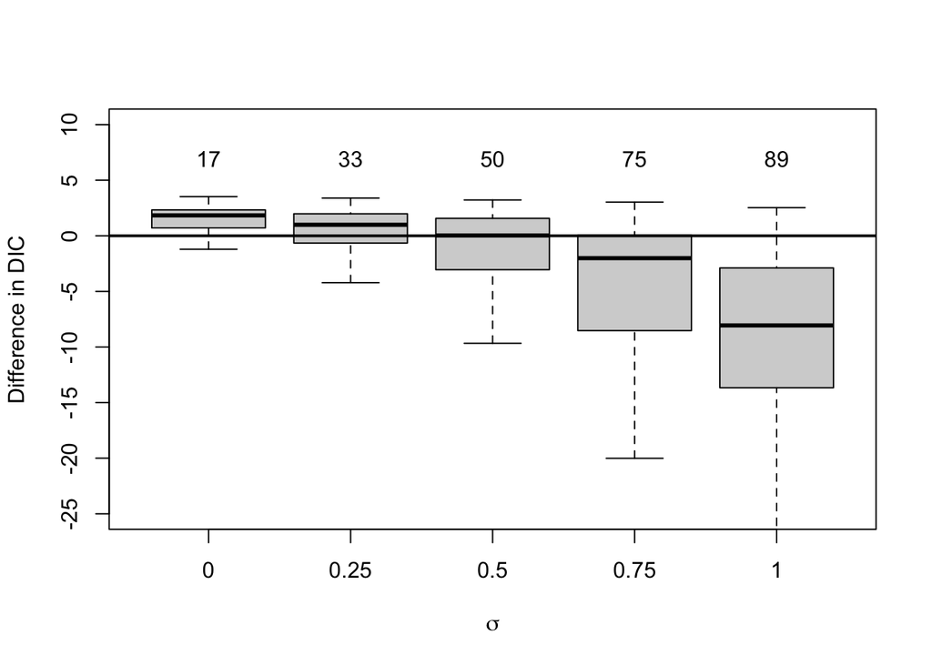

```r
DIC_diff <- DIC[,2,]-DIC[,1,]
DIC_pick_RE <- colMeans(DIC_diff<0,na.rm=TRUE)

WAIC_diff <- WAIC[,2,]-WAIC[,1,]
WAIC_pick_RE <- colMeans(WAIC_diff<0,na.rm=TRUE)

SIG <- matrix(sigma, N, ns, byrow=TRUE)
boxplot(DIC_diff~SIG, ylim=c(-25,10), outline=FALSE,
        xlab=expression(sigma), ylab="Difference in DIC")
abline(0,0,lwd=2)
text(1:ns,rep(5,ns),round(100*DIC_pick_RE),pos=3)
```

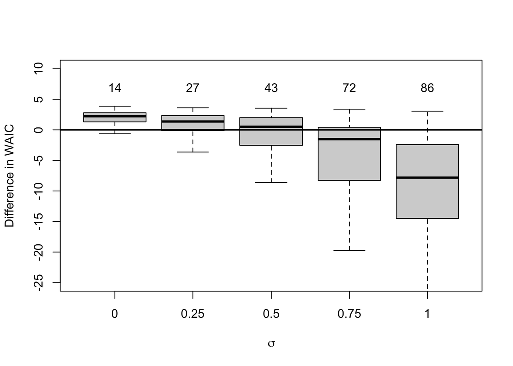

```r
boxplot(WAIC_diff~SIG, ylim=c(-25,10), outline=FALSE,
        xlab=expression(sigma), ylab="Difference in WAIC")
abline(0,0,lwd=2)
text(1:ns,rep(5,ns),round(100*WAIC_pick_RE),pos=3)
```